# Linear Regression

- Linear regression is used to predict a value based on the given data.
- It basically fits a straight line (or a multi-dimensional plane) to the data and predicts the values using that.

## Applications

It may be used in the following usecases:

- House price prediction
- Car price prediction
- Inside a deep learning neural network (in the form of "linear" or "ReLU" node)
- Marks prediction ...etc

## What we have to achieve using linear regression

We have a data, now we have to fit a straight line in the form:

$$\Large{y} = \Large{\vec{w}}.\Large{\vec{x}} + \Large{b}$$

And we have to find the values of `w` and `b` of the equation.

In this file, we will only focus on data with 1 or 2 features (as it is not possible to represent graphs beyond 3D). After we find the values of `w` and `b`. The result should look something like below for the assumed data.

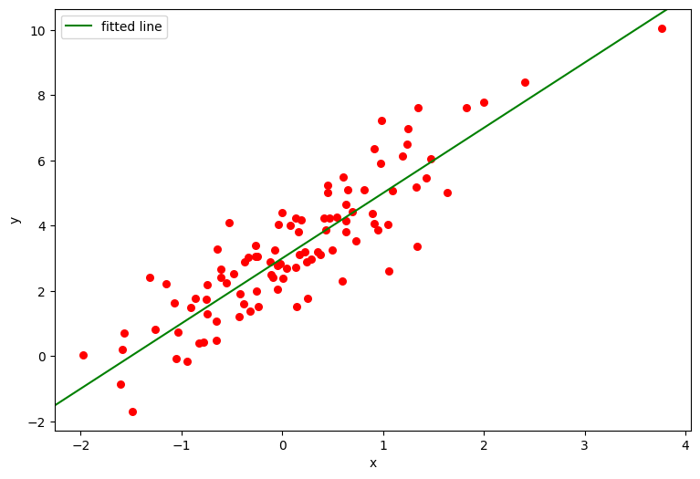

```python
%matplotlib inline
import matplotlib.pyplot as plt
import numpy as np

X = np.random.randn(1,100)
Y = 2 * X + 3 + np.random.randn(1,100)

# Plotting x, y on the plot
def showLineOnData(x, y, w, b, lines=[]):
    fig, ax = plt.subplots(figsize=(9,6))

    if(len(lines) != 0):
        for i in range(len(lines)):
            ax.axline((0, lines[i][1]), slope=lines[i][0], linewidth=1)

    ax.axline((0, b), slope=w, color='g', label='fitted line')

    ax.scatter(x, y, color="r", s=30)
    plt.xlabel('x')
    plt.ylabel('y')
    plt.legend()

showLineOnData(X, Y, 2, 3)
plt.show()
```

## The Maths

### How to fit a line ?

Let the data be:

| x(Feature) |  | y(Label) |
| --- | --- | --- |
| 1 |  | 5 |
| 2 |  | 7 |
| 3 |  | 9 |
| 4 |  | 11 |
| 5 |  | 13 |
| 6 |  | 15 |
| 7 |  | 17 |

```python
x = [1,2,3,4,5,6,7]
y = [5,7,9,11,13,15,17]
```

Now we have to fit a straight line (find `w` and `b`) accross the points plotted between `x` and `y` such that the total error (known as cost) between the predicted values of the line and the actual value is reduced.

The error between the actual value and the hypothesis can be found out using the loss function:

$$\Large{ loss = {1 \over 2} (f(x) - y)^2 } $$

So the total loss of all the data points can be given by:-

$$\Large{ J(w,b) = \sum \limits _{i=1} ^{n} {1 \over 2} (f(x_{i}) - y_{i}) ^{2} } $$

Now, out goal is to reduce this cost function as much possible, and find `w` and `b` such that the cost is minimum.

### For reducing the cost function:

First let us visulize the relation between the cost function(`J(w,b)`) and the parameters `w` and `b`.

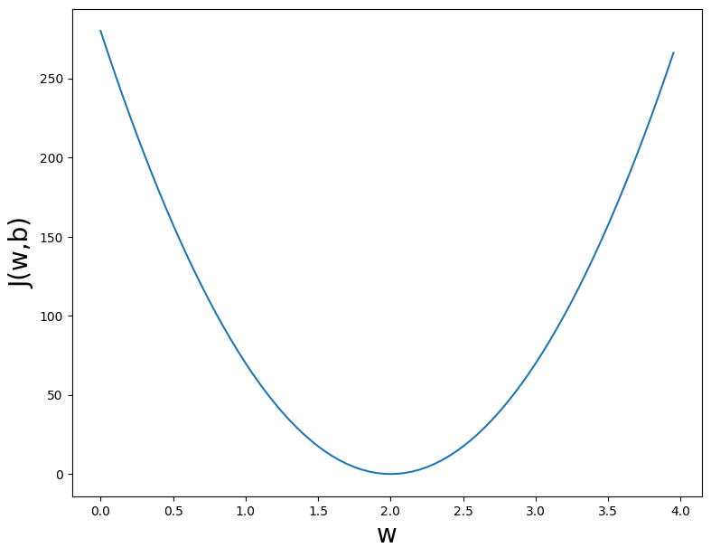

```python
# Calculating the cost for each w between 0 and 4
w = np.arange(0,4,0.05).astype(float)
# w = [0.05, 0.1, 0.15,0.2....,4]

# assuming b to be a random constant
b = 3

def J(w, b):
    cost = 0
    for i in range(len(x)):
        cost += 0.5 * (((w*x[i] + b) - y[i]) ** 2)
    return cost

# Calculating the cost function for each w
cost = [0.0]*len(w)
for i in range(len(w)):
    cost[i] += J(w[i], b)

plt.figure(figsize = (9,7))
plt.plot(w,cost)
plt.xlabel("w",size=20)
plt.ylabel("J(w,b)",size=20)
plt.show()
```

# Relation between w, b and cost

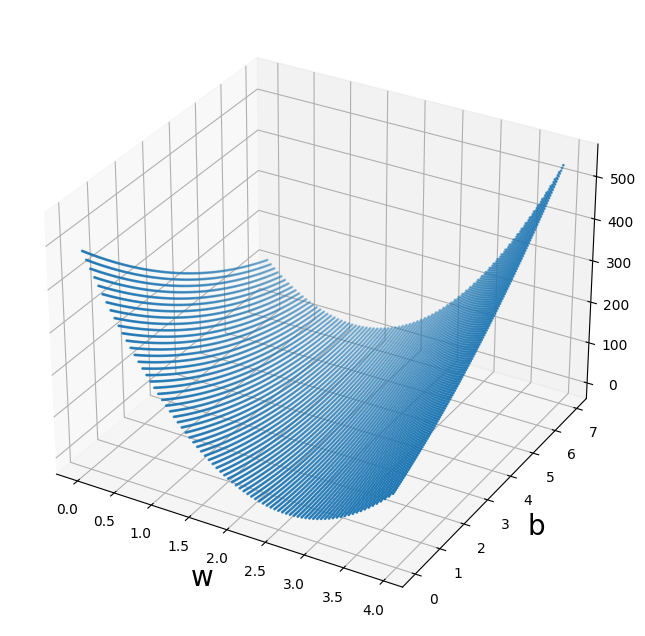

```python
# a range of possible values of w
w = np.arange(0,4,0.05).astype(float)

# a range of possible values of b
b = np.arange(0,7,0.05).astype(float)

# calculating all the values of cost for every w and b combination
Cost =[0.0]*(len(w)*len(b))
W =[0.0]*(len(w)*len(b))
B =[0.0]*(len(w)*len(b))
c=0
for i in range(len(w)):
    for k in range(len(b)):
        Cost[c] = J(w[i], b[k])
        W[c] = w[i]
        B[c] = b[k]
        c+=1

plt.figure(figsize=(9,8))
ax = plt.axes(projection="3d")
plt.xlabel("w",fontsize=20)
plt.ylabel("b",fontsize=20)

ax.scatter3D(W,B,Cost, depthshade=True, s=1)

plt.show()
```

Now, Assume any point value of `w` and `b`, and calculate J(w,b) for that, this point will lie on the curve. To improve the position of this point and to take it towards the minima, we have take small steps towards that direction.

```python
# Let
w_assumed = 1
b_assumed = 2
```

### Plotting the point on the graph:

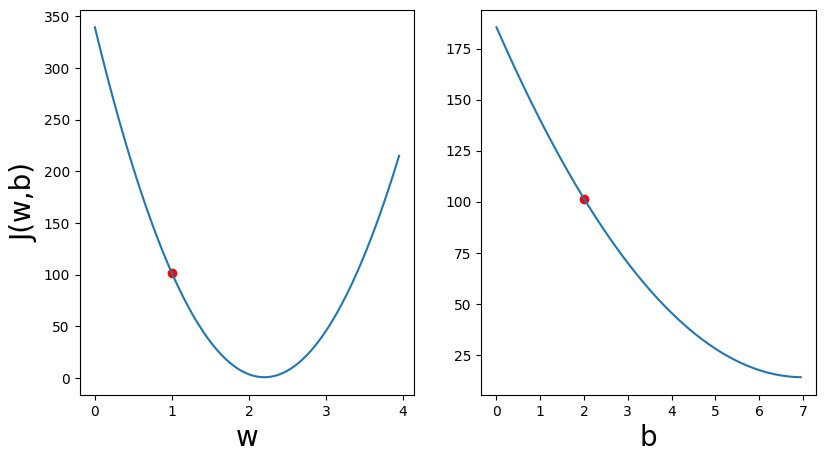

```python
def showGraph(w_assumed, b_assumed, points=[]):
    # a range of possible values of w
    w = np.arange(0,4,0.05).astype(float)

    # a range of possible values of b
    b = np.arange(0,7,0.05).astype(float)

    cost1 = [0.0]*len(w)
    for i in range(len(w)):
        cost1[i] += J(w[i], b_assumed)

    plt.figure(figsize=(9.5,5))
    plt.subplot(1,2,1)
    plt.plot(w,cost1)
    plt.scatter(w_assumed, J(w_assumed, b_assumed), color="r")

    if(len(points) != 0):
        for p in points:
            plt.scatter(p[0], J(w_assumed, b_assumed), color="r", s=5)

    plt.xlabel("w",size=20)
    plt.ylabel("J(w,b)",size=20)

    cost2 = [0.0]*len(b)
    for i in range(len(b)):
        cost2[i] += J(w_assumed, b[i])

    plt.subplot(1,2,2)
    plt.plot(b,cost2)
    plt.scatter(b_assumed, J(w_assumed, b_assumed), color="r")

    if(len(points) != 0):
        for p in points:
            plt.scatter(p[1], J(w_assumed, b_assumed), color="r",s=5)

    plt.xlabel("b",size=20)

showGraph(w_assumed, b_assumed)
plt.show()
```

### To understand in 3D:

We can plot a graph of w, b, J(w,b)

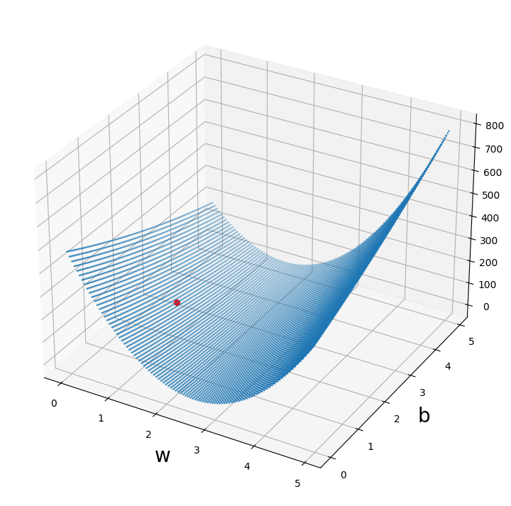

```python
def show3DGraph(w_assumed, b_assumed, points=[]):
    # a range of possible values of w
    w = np.arange(0,5,0.05).astype(float)

    # a range of possible values of b
    b = np.arange(0,5,0.05).astype(float)

    # calculating all the values of cost for every w and b combination
    Cost =[0.0]*(len(w)*len(b))
    W =[0.0]*(len(w)*len(b))
    B =[0.0]*(len(w)*len(b))
    c=0
    for i in range(len(w)):
        for k in range(len(b)):
            Cost[c] = J(w[i], b[k])
            W[c] = w[i]
            B[c] = b[k]
            c+=1

    fig = plt.figure(figsize=(9,9))

    ax = plt.axes(projection="3d")
    ax.scatter(w_assumed, b_assumed, J(w_assumed, b_assumed), c="r", s=30)
    if(len(points) != 0):
        for p in points:
            ax.scatter(p[0], p[1], J(p[0], p[1]), c="r", s=5)
    plt.xlabel("w",fontsize=20)
    plt.ylabel("b",fontsize=20)
    ax.scatter3D(W,B,Cost, depthshade=True, s=1)

show3DGraph(w_assumed, b_assumed)
plt.show()
```

Now the goal is to find the direction in which the minima lies, To do this we can find the partial derivative of cost function (J(w,b)) with respect to `w` and `b` separately and move towards that direction by a little bit.

**We know that lines which inercept, the x-axis at < 90deg have +ve slope and vice-verse.**

So, in order to move the point towards the minima we can subtract that small step from the initial `w` and `b` to move towards minima.So,

$$ \Large{ w = w - \alpha { \partial J(w,b) \over \partial w } } ........... (i) $$

$$ \Large{ b = b - \alpha { \partial J(w,b) \over \partial b } } ........... (ii) $$

Where, **α** is the learning rate (to make the step smaller, we use **0.0001 <= α <= 0.1** in most cases)

**For simplification**:

- Partial derivative with respect to b:

$ { \partial J(w,b) \over \partial b } = { \partial \over \partial b } { 1 \over 2 } (wx + b - y) ^{2} $

$ = (f(x) - y) $

- Partial derivative with respect to w:

$ { \partial J(w,b) \over \partial w } = { \partial \over \partial w } { 1 \over 2 } (wx + b - y) ^{2} $

$ = (wx + b - y)x $

$ = (f(x) - y)x $

Putting the above back into equation (i) and (ii) will give:

$$\Large{ w = w - \alpha(f(x) - y)x } $$

$$\Large{ b = b - \alpha(f(x) - y) } $$

Now, for actualling using these equations, we have to get the average of all the errors (**Note:** We have to find only one `w` and `b`, but the errors we are finding is with all the points instead, so for getting a single inference out of all the errors, we have to find the mean of all the derivatives of erros)

So, after calculating the mean the equations can be written as follows:

$$\Large{ w = w - \alpha \sum \limits _{i=1} ^{n} { (f(x) - y)x \over n } } $$

$$\Large{ b = b - \alpha \sum \limits _{i=1} ^{n} { (f(x) - y) \over n } } $$

Now we can repeat find `w` and `b` from the above equation, by repeating it till the parameters stop changing.

Once we have reached minima, we have the final values of `w` and `b` and now we can use these values for predicting the output value based on the given feature `x`

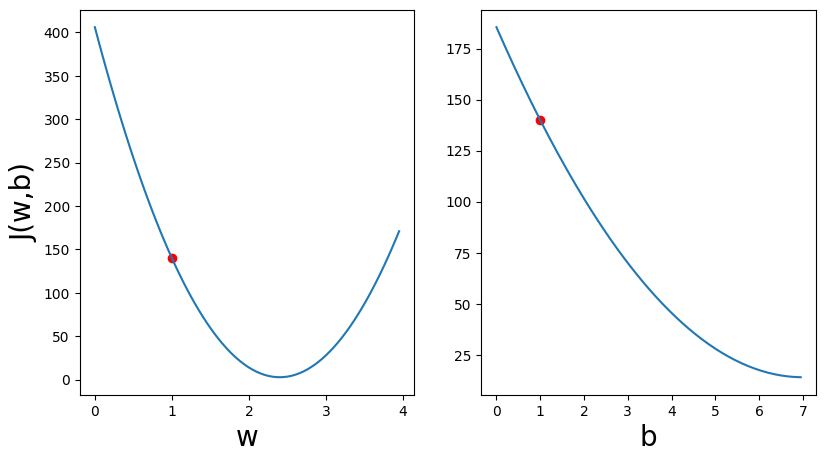

```python
alpha = 0.01

w_assumed = 1
b_assumed = 1

showGraph(w_assumed, b_assumed)
plt.show()
```

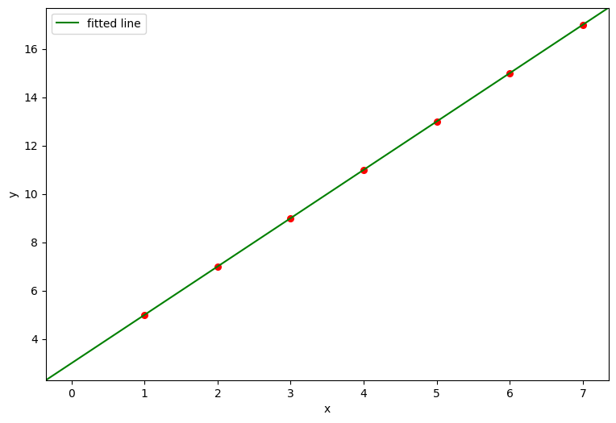

```python
def findError(w, b):
    w_err = 0
    b_err = 0
    for i in range(len(x)):
        w_err += ((w*x[i] + b) - y[i])*x[i]
        b_err += ((w*x[i] + b) - y[i])
    return w_err/len(x), b_err/len(x)

points = []

for i in range(5000):
    w_err, b_err = findError(w_assumed, b_assumed)
    w_assumed = w_assumed - alpha * w_err
    b_assumed = b_assumed - alpha * b_err

    # creating a list of these points
    if(i<5 or i%200==0):
        points.append([w_assumed, b_assumed])

showLineOnData(x, y, w_assumed, b_assumed)
plt.show()
```

# Summary

Now we will make a linear regression model ourselves, similar to that present on sci-kit learn

```python
# defining a class Linear Regression
class LinearRegression:

    def __init__(self):
        self.w = 0
        self.b = 0
        self.alpha = 0.0000000001
        self.n= 1000

    def f(self, x):
        return self.w*x + self.b

    def find_error(self, x, y):
        w_err = 0
        b_err = 0
        for i in range(len(x)):
            w_err += (self.f(x[i]) - y[i])*x[i]
            b_err += (self.f(x[i]) - y[i])
        return w_err/len(x), b_err/len(x)

    def fit(self, x, y):
        for _ in range(self.n):
            w_err, b_err = self.find_error(x, y)
            self.w -= self.alpha * w_err
            self.b -= self.alpha * b_err

    def predict(self, x):
        prediction = []
        for inpt in x:
            prediction.append(self.f(inpt))
        return prediction
```

```python
from google.colab import drive
drive.mount('/content/drive')
```

```python
import pandas as pd
import numpy as np

df = pd.read_csv("/content/drive/MyDrive/datasets/Housing.csv")
df.sample(5)
```

|  | price | area |
| --- | --- | --- |
| 526 | 2310000 | 3180 |
| 286 | 4235000 | 2787 |
| 327 | 3990000 | 6480 |
| 167 | 5285000 | 4600 |
| 539 | 1855000 | 2990 |

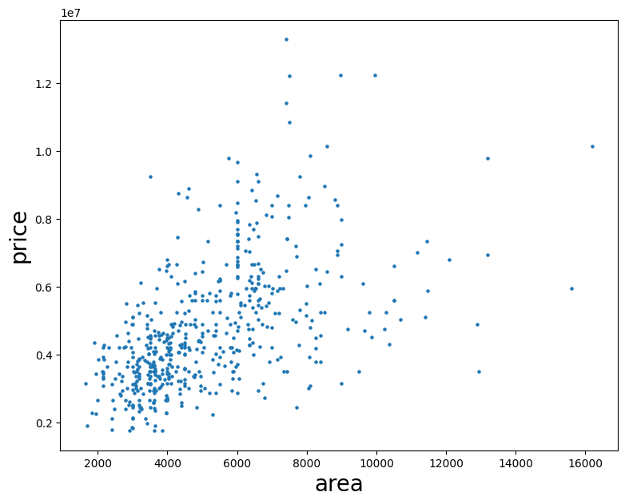

```python
plt.figure(figsize = (9,7))
plt.scatter(df["area"], df["price"], s=5)
plt.xlabel("area",size=20)
plt.ylabel("price",size=20)
plt.show()
```

```python
x = df["area"]
y = df["price"]
```

```python
model = LinearRegression()

x_train = x[:400].values.tolist()
x_test = x[400:].values.tolist()

y_train = y[:400].values.tolist()
y_test = y[400:].values.tolist()
```

```python
model.fit(x_train, y_train)
```

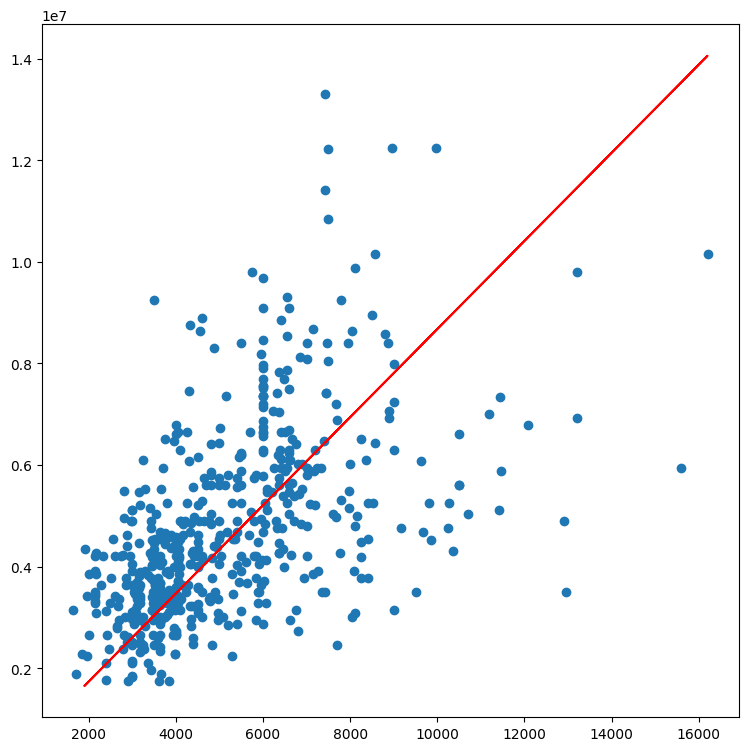

```python
x_train_pred = model.predict(x_train)

plt.figure(figsize=(9,9))
plt.scatter(x, y)
plt.plot(x_train, x_train_pred, c="r")
plt.show()
```

### Prediciton system

```python
# Creating a prediction system

house_area = int(input("Enter the area of the house: "))
price = model.predict([house_area])[0]

f"The Price of the house is {price}"
```

```
Enter the area of the house: 25000
```

```
'The Price of the house is 21695199.546535496'
```